## Predicting Crop Growth Using Weather Data

# Introduction

Welcome to the Crop Growth Prediction project! Our objective is to create a smart tool using weather history and crop yield data to predict crop growth. By combining these datasets, we'll develop a machine learning model that forecasts crop performance based on past weather conditions.

Understanding how weather influences crops is crucial for smarter farming practices, offering farmers valuable insights to navigate unpredictable weather and optimize their yields.

## Data Manipulation and Visualization

Let's start by importing the necessary libraries for data manipulation and visualization.

```python
import pandas as pd
import numpy as np

from sklearn.impute import KNNImputer
from sklearn.preprocessing import MinMaxScaler
from sklearn.cluster import KMeans
from sklearn.preprocessing import StandardScaler
from sklearn.ensemble import RandomForestRegressor
from sklearn.preprocessing import LabelEncoder
from sklearn.model_selection import train_test_split

from sklearn.linear_model import LinearRegression
from sklearn.metrics import mean_squared_error, r2_score

import matplotlib.pyplot as plt
import seaborn as sns

from scipy.stats import boxcox
from scipy.stats import skew
```

## Data Preprocessing

Loading and Displaying Crop Yield Data

```python
yield_df = pd.read_csv("project/crop yield/yield_df.csv")
yield_df.head()
```

|  | Unnamed: 0 | Area | Item | Year | hg/ha_yield | average_rain_fall_mm_per_year | pesticides_tonnes | avg_temp |
| --- | --- | --- | --- | --- | --- | --- | --- | --- |
| 0 | 0 | Albania | Maize | 1990 | 36613 | 1485.0 | 121.0 | 16.37 |
| 1 | 1 | Albania | Potatoes | 1990 | 66667 | 1485.0 | 121.0 | 16.37 |
| 2 | 2 | Albania | Rice, paddy | 1990 | 23333 | 1485.0 | 121.0 | 16.37 |
| 3 | 3 | Albania | Sorghum | 1990 | 12500 | 1485.0 | 121.0 | 16.37 |
| 4 | 4 | Albania | Soybeans | 1990 | 7000 | 1485.0 | 121.0 | 16.37 |

Dropping Columns from Crop Yield Data

```python
yield_df.drop(columns=["Unnamed: 0","Item"], inplace=True)
```

Filtering Crop Yield Data for Canada (2006 - 2016)

```python
yield_df_canada = yield_df[(yield_df['Year'] >= 2006) & (yield_df['Year'] <= 2016) & (yield_df['Area'] == 'Canada')]
yield_df_canada
```

|  | Area | Year | hg/ha_yield | average_rain_fall_mm_per_year | pesticides_tonnes | avg_temp |
| --- | --- | --- | --- | --- | --- | --- |
| 5938 | Canada | 2006 | 84737 | 537.0 | 36572.75 | 8.66 |
| 5939 | Canada | 2006 | 84737 | 537.0 | 36572.75 | 9.83 |
| 5940 | Canada | 2006 | 84737 | 537.0 | 36572.75 | 6.95 |
| 5941 | Canada | 2006 | 84737 | 537.0 | 36572.75 | 6.30 |
| 5942 | Canada | 2006 | 84737 | 537.0 | 36572.75 | 7.85 |
| ... | ... | ... | ... | ... | ... | ... |
| 6125 | Canada | 2013 | 35943 | 537.0 | 81659.80 | 10.11 |
| 6126 | Canada | 2013 | 35943 | 537.0 | 81659.80 | 7.86 |
| 6127 | Canada | 2013 | 35943 | 537.0 | 81659.80 | 7.08 |
| 6128 | Canada | 2013 | 35943 | 537.0 | 81659.80 | 8.46 |
| 6129 | Canada | 2013 | 35943 | 537.0 | 81659.80 | 9.85 |

192 rows × 6 columns

```python
yield_df_canada.describe()
```

|  | Year | hg/ha_yield | average_rain_fall_mm_per_year | pesticides_tonnes | avg_temp |
| --- | --- | --- | --- | --- | --- |
| count | 192.000000 | 192.000000 | 192.0 | 192.000000 | 192.000000 |
| mean | 2009.500000 | 68293.156250 | 537.0 | 58534.422500 | 7.604375 |
| std | 2.297278 | 42494.154486 | 0.0 | 13633.238055 | 1.410009 |
| min | 2006.000000 | 23010.000000 | 537.0 | 36572.750000 | 4.710000 |
| 25% | 2007.750000 | 28627.500000 | 537.0 | 51565.482500 | 6.695000 |
| 50% | 2009.500000 | 59833.000000 | 537.0 | 57789.700000 | 7.610000 |
| 75% | 2011.250000 | 103132.750000 | 537.0 | 64957.625000 | 8.617500 |
| max | 2013.000000 | 132270.000000 | 537.0 | 81659.800000 | 10.510000 |

Loading and Displaying Another Crop Yield Dataset

```python
_yield = pd.read_csv("project/crop yield/yield.csv")
_yield.head()
```

|  | Domain Code | Domain | Area Code | Area | Element Code | Element | Item Code | Item | Year Code | Year | Unit | Value |
| --- | --- | --- | --- | --- | --- | --- | --- | --- | --- | --- | --- | --- |
| 0 | QC | Crops | 2 | Afghanistan | 5419 | Yield | 56 | Maize | 1961 | 1961 | hg/ha | 14000 |
| 1 | QC | Crops | 2 | Afghanistan | 5419 | Yield | 56 | Maize | 1962 | 1962 | hg/ha | 14000 |
| 2 | QC | Crops | 2 | Afghanistan | 5419 | Yield | 56 | Maize | 1963 | 1963 | hg/ha | 14260 |
| 3 | QC | Crops | 2 | Afghanistan | 5419 | Yield | 56 | Maize | 1964 | 1964 | hg/ha | 14257 |
| 4 | QC | Crops | 2 | Afghanistan | 5419 | Yield | 56 | Maize | 1965 | 1965 | hg/ha | 14400 |

Dropping Columns from Another Crop Yield Dataset

```python
_yield.drop(columns=["Domain Code","Domain","Area Code","Element Code","Item","Year Code","Unit","Item Code","Element"], inplace=True)
```

Filtering Another Crop Yield Dataset for Canada (2006 - 2016)

```python
_yield_canada = _yield[(_yield['Year'] >= 2006) & (_yield['Year'] <= 2016) & (_yield['Area'] == 'Canada')]
_yield_canada
```

|  | Area | Year | Value |
| --- | --- | --- | --- |
| 8598 | Canada | 2006 | 84737 |
| 8599 | Canada | 2007 | 85108 |
| 8600 | Canada | 2008 | 90623 |
| 8601 | Canada | 2009 | 83723 |
| 8602 | Canada | 2010 | 97385 |
| 8603 | Canada | 2011 | 88946 |
| 8604 | Canada | 2012 | 92109 |
| 8605 | Canada | 2013 | 95878 |
| 8606 | Canada | 2014 | 93647 |
| 8607 | Canada | 2015 | 103370 |
| 8608 | Canada | 2016 | 93719 |
| 8654 | Canada | 2006 | 130482 |
| 8655 | Canada | 2007 | 126498 |
| 8656 | Canada | 2008 | 126065 |
| 8657 | Canada | 2009 | 127453 |
| 8658 | Canada | 2010 | 128373 |
| 8659 | Canada | 2011 | 120376 |
| 8660 | Canada | 2012 | 124735 |
| 8661 | Canada | 2013 | 132270 |
| 8662 | Canada | 2014 | 133611 |
| 8663 | Canada | 2015 | 126175 |
| 8664 | Canada | 2016 | 126285 |
| 8710 | Canada | 2006 | 28850 |
| 8711 | Canada | 2007 | 23010 |
| 8712 | Canada | 2008 | 27906 |
| 8713 | Canada | 2009 | 25371 |
| 8714 | Canada | 2010 | 29515 |
| 8715 | Canada | 2011 | 28738 |
| 8716 | Canada | 2012 | 30294 |
| 8717 | Canada | 2013 | 28810 |
| 8718 | Canada | 2014 | 27062 |
| 8719 | Canada | 2015 | 28993 |
| 8720 | Canada | 2016 | 26602 |
| 8766 | Canada | 2006 | 26096 |
| 8767 | Canada | 2007 | 23317 |
| 8768 | Canada | 2008 | 28575 |
| 8769 | Canada | 2009 | 27897 |
| 8770 | Canada | 2010 | 28085 |
| 8771 | Canada | 2011 | 29568 |
| 8772 | Canada | 2012 | 28645 |
| 8773 | Canada | 2013 | 35943 |
| 8774 | Canada | 2014 | 31033 |
| 8775 | Canada | 2015 | 28812 |
| 8776 | Canada | 2016 | 32917 |

```python
_yield_canada.describe()
```

|  | Year | Value |
| --- | --- | --- |
| count | 44.000000 | 44.000000 |
| mean | 2011.000000 | 69036.522727 |
| std | 3.198837 | 43170.700416 |
| min | 2006.000000 | 23010.000000 |
| 25% | 2008.000000 | 28714.750000 |
| 50% | 2011.000000 | 59833.000000 |
| 75% | 2014.000000 | 107621.500000 |
| max | 2016.000000 | 133611.000000 |

Loading Weather Data

```python
weather_df = pd.read_csv("project/weather/weatherHistory.csv")
```

```python
weather_df.drop(columns=["Apparent Temperature (C)","Wind Bearing (degrees)","Daily Summary"], inplace=True)
```

```python
weather_df
```

|  | Formatted Date | Summary | Precip Type | Temperature (C) | Humidity | Wind Speed (km/h) | Visibility (km) | Loud Cover | Pressure (millibars) |
| --- | --- | --- | --- | --- | --- | --- | --- | --- | --- |
| 0 | 2006-04-01 00:00:00.000 +0200 | Partly Cloudy | rain | 9.472222 | 0.89 | 14.1197 | 15.8263 | 0.0 | 1015.13 |
| 1 | 2006-04-01 01:00:00.000 +0200 | Partly Cloudy | rain | 9.355556 | 0.86 | 14.2646 | 15.8263 | 0.0 | 1015.63 |
| 2 | 2006-04-01 02:00:00.000 +0200 | Mostly Cloudy | rain | 9.377778 | 0.89 | 3.9284 | 14.9569 | 0.0 | 1015.94 |
| 3 | 2006-04-01 03:00:00.000 +0200 | Partly Cloudy | rain | 8.288889 | 0.83 | 14.1036 | 15.8263 | 0.0 | 1016.41 |
| 4 | 2006-04-01 04:00:00.000 +0200 | Mostly Cloudy | rain | 8.755556 | 0.83 | 11.0446 | 15.8263 | 0.0 | 1016.51 |
| ... | ... | ... | ... | ... | ... | ... | ... | ... | ... |
| 96448 | 2016-09-09 19:00:00.000 +0200 | Partly Cloudy | rain | 26.016667 | 0.43 | 10.9963 | 16.1000 | 0.0 | 1014.36 |
| 96449 | 2016-09-09 20:00:00.000 +0200 | Partly Cloudy | rain | 24.583333 | 0.48 | 10.0947 | 15.5526 | 0.0 | 1015.16 |
| 96450 | 2016-09-09 21:00:00.000 +0200 | Partly Cloudy | rain | 22.038889 | 0.56 | 8.9838 | 16.1000 | 0.0 | 1015.66 |
| 96451 | 2016-09-09 22:00:00.000 +0200 | Partly Cloudy | rain | 21.522222 | 0.60 | 10.5294 | 16.1000 | 0.0 | 1015.95 |
| 96452 | 2016-09-09 23:00:00.000 +0200 | Partly Cloudy | rain | 20.438889 | 0.61 | 5.8765 | 15.5204 | 0.0 | 1016.16 |

96453 rows × 9 columns

Formatting Weather Data

```python
weather_df['Formatted Date'] = pd.to_datetime(weather_df['Formatted Date'], utc=True)
weather_df['Year'] = weather_df['Formatted Date'].dt.year
weather_df.drop(columns=['Formatted Date'],inplace=True)
weather_df
```

|  | Summary | Precip Type | Temperature (C) | Humidity | Wind Speed (km/h) | Visibility (km) | Loud Cover | Pressure (millibars) | Year |
| --- | --- | --- | --- | --- | --- | --- | --- | --- | --- |
| 0 | Partly Cloudy | rain | 9.472222 | 0.89 | 14.1197 | 15.8263 | 0.0 | 1015.13 | 2006 |
| 1 | Partly Cloudy | rain | 9.355556 | 0.86 | 14.2646 | 15.8263 | 0.0 | 1015.63 | 2006 |
| 2 | Mostly Cloudy | rain | 9.377778 | 0.89 | 3.9284 | 14.9569 | 0.0 | 1015.94 | 2006 |
| 3 | Partly Cloudy | rain | 8.288889 | 0.83 | 14.1036 | 15.8263 | 0.0 | 1016.41 | 2006 |
| 4 | Mostly Cloudy | rain | 8.755556 | 0.83 | 11.0446 | 15.8263 | 0.0 | 1016.51 | 2006 |
| ... | ... | ... | ... | ... | ... | ... | ... | ... | ... |
| 96448 | Partly Cloudy | rain | 26.016667 | 0.43 | 10.9963 | 16.1000 | 0.0 | 1014.36 | 2016 |
| 96449 | Partly Cloudy | rain | 24.583333 | 0.48 | 10.0947 | 15.5526 | 0.0 | 1015.16 | 2016 |
| 96450 | Partly Cloudy | rain | 22.038889 | 0.56 | 8.9838 | 16.1000 | 0.0 | 1015.66 | 2016 |
| 96451 | Partly Cloudy | rain | 21.522222 | 0.60 | 10.5294 | 16.1000 | 0.0 | 1015.95 | 2016 |
| 96452 | Partly Cloudy | rain | 20.438889 | 0.61 | 5.8765 | 15.5204 | 0.0 | 1016.16 | 2016 |

96453 rows × 9 columns

```python
weather_df.describe()
```

|  | Temperature (C) | Humidity | Wind Speed (km/h) | Visibility (km) | Loud Cover | Pressure (millibars) | Year |
| --- | --- | --- | --- | --- | --- | --- | --- |
| count | 96453.000000 | 96453.000000 | 96453.000000 | 96453.000000 | 96453.0 | 96453.000000 | 96453.00000 |
| mean | 11.932678 | 0.734899 | 10.810640 | 10.347325 | 0.0 | 1003.235956 | 2011.00029 |
| std | 9.551546 | 0.195473 | 6.913571 | 4.192123 | 0.0 | 116.969906 | 3.16216 |
| min | -21.822222 | 0.000000 | 0.000000 | 0.000000 | 0.0 | 0.000000 | 2005.00000 |
| 25% | 4.688889 | 0.600000 | 5.828200 | 8.339800 | 0.0 | 1011.900000 | 2008.00000 |
| 50% | 12.000000 | 0.780000 | 9.965900 | 10.046400 | 0.0 | 1016.450000 | 2011.00000 |
| 75% | 18.838889 | 0.890000 | 14.135800 | 14.812000 | 0.0 | 1021.090000 | 2014.00000 |
| max | 39.905556 | 1.000000 | 63.852600 | 16.100000 | 0.0 | 1046.380000 | 2016.00000 |

Combining Crop Yield Data for Canada

```python
merged_df = pd.merge(yield_df_canada, _yield_canada, how='inner', on='Year')
merged_df
```

|  | Area_x | Year | hg/ha_yield | average_rain_fall_mm_per_year | pesticides_tonnes | avg_temp | Area_y | Value |
| --- | --- | --- | --- | --- | --- | --- | --- | --- |
| 0 | Canada | 2006 | 84737 | 537.0 | 36572.75 | 8.66 | Canada | 84737 |
| 1 | Canada | 2006 | 84737 | 537.0 | 36572.75 | 8.66 | Canada | 130482 |
| 2 | Canada | 2006 | 84737 | 537.0 | 36572.75 | 8.66 | Canada | 28850 |
| 3 | Canada | 2006 | 84737 | 537.0 | 36572.75 | 8.66 | Canada | 26096 |
| 4 | Canada | 2006 | 84737 | 537.0 | 36572.75 | 9.83 | Canada | 84737 |
| ... | ... | ... | ... | ... | ... | ... | ... | ... |
| 763 | Canada | 2013 | 35943 | 537.0 | 81659.80 | 8.46 | Canada | 35943 |
| 764 | Canada | 2013 | 35943 | 537.0 | 81659.80 | 9.85 | Canada | 95878 |
| 765 | Canada | 2013 | 35943 | 537.0 | 81659.80 | 9.85 | Canada | 132270 |
| 766 | Canada | 2013 | 35943 | 537.0 | 81659.80 | 9.85 | Canada | 28810 |
| 767 | Canada | 2013 | 35943 | 537.0 | 81659.80 | 9.85 | Canada | 35943 |

768 rows × 8 columns

Combining Crop Yield and Weather Data

```python
final_merged_df = pd.merge(merged_df, weather_df, how='inner', on='Year')
```

```python
final_merged_df
```

|  | Area_x | Year | hg/ha_yield | average_rain_fall_mm_per_year | pesticides_tonnes | avg_temp | Area_y | Value | Summary | Precip Type | Temperature (C) | Humidity | Wind Speed (km/h) | Visibility (km) | Loud Cover | Pressure (millibars) |
| --- | --- | --- | --- | --- | --- | --- | --- | --- | --- | --- | --- | --- | --- | --- | --- | --- |
| 0 | Canada | 2006 | 84737 | 537.0 | 36572.75 | 8.66 | Canada | 84737 | Partly Cloudy | rain | 9.472222 | 0.89 | 14.1197 | 15.8263 | 0.0 | 1015.13 |
| 1 | Canada | 2006 | 84737 | 537.0 | 36572.75 | 8.66 | Canada | 84737 | Partly Cloudy | rain | 9.355556 | 0.86 | 14.2646 | 15.8263 | 0.0 | 1015.63 |
| 2 | Canada | 2006 | 84737 | 537.0 | 36572.75 | 8.66 | Canada | 84737 | Mostly Cloudy | rain | 9.377778 | 0.89 | 3.9284 | 14.9569 | 0.0 | 1015.94 |
| 3 | Canada | 2006 | 84737 | 537.0 | 36572.75 | 8.66 | Canada | 84737 | Partly Cloudy | rain | 8.288889 | 0.83 | 14.1036 | 15.8263 | 0.0 | 1016.41 |
| 4 | Canada | 2006 | 84737 | 537.0 | 36572.75 | 8.66 | Canada | 84737 | Mostly Cloudy | rain | 8.755556 | 0.83 | 11.0446 | 15.8263 | 0.0 | 1016.51 |
| ... | ... | ... | ... | ... | ... | ... | ... | ... | ... | ... | ... | ... | ... | ... | ... | ... |
| 6734587 | Canada | 2013 | 35943 | 537.0 | 81659.80 | 9.85 | Canada | 35943 | Mostly Cloudy | rain | 15.916667 | 0.89 | 10.4650 | 8.3076 | 0.0 | 1018.88 |
| 6734588 | Canada | 2013 | 35943 | 537.0 | 81659.80 | 9.85 | Canada | 35943 | Mostly Cloudy | rain | 14.816667 | 0.88 | 13.9909 | 6.0214 | 0.0 | 1019.24 |
| 6734589 | Canada | 2013 | 35943 | 537.0 | 81659.80 | 9.85 | Canada | 35943 | Mostly Cloudy | rain | 14.283333 | 0.90 | 6.2468 | 6.8747 | 0.0 | 1019.34 |
| 6734590 | Canada | 2013 | 35943 | 537.0 | 81659.80 | 9.85 | Canada | 35943 | Partly Cloudy | rain | 12.900000 | 0.93 | 3.6547 | 7.6475 | 0.0 | 1019.48 |
| 6734591 | Canada | 2013 | 35943 | 537.0 | 81659.80 | 9.85 | Canada | 35943 | Clear | rain | 0.572222 | 0.89 | 13.5562 | 7.7280 | 0.0 | 1024.47 |

6734592 rows × 16 columns

```python
final_merged_df.drop(columns=["Area_x","Area_y","Precip Type","Loud Cover","Value"],inplace=True)
```

# EDA

```python
final_merged_df.info()
```

```
<class 'pandas.core.frame.DataFrame'>
Int64Index: 6734592 entries, 0 to 6734591
Data columns (total 11 columns):
 #   Column                         Dtype
---  ------                         -----
 0   Year                           int64
 1   hg/ha_yield                    int64
 2   average_rain_fall_mm_per_year  float64
 3   pesticides_tonnes              float64
 4   avg_temp                       float64
 5   Summary                        object
 6   Temperature (C)                float64
 7   Humidity                       float64
 8   Wind Speed (km/h)              float64
 9   Visibility (km)                float64
 10  Pressure (millibars)           float64
dtypes: float64(8), int64(2), object(1)
memory usage: 616.6+ MB
```

```python
final_merged_df.describe()
```

|  | Year | hg/ha_yield | average_rain_fall_mm_per_year | pesticides_tonnes | avg_temp | Temperature (C) | Humidity | Wind Speed (km/h) | Visibility (km) | Pressure (millibars) |
| --- | --- | --- | --- | --- | --- | --- | --- | --- | --- | --- |
| count | 6.734592e+06 | 6.734592e+06 | 6734592.0 | 6.734592e+06 | 6.734592e+06 | 6.734592e+06 | 6.734592e+06 | 6.734592e+06 | 6.734592e+06 | 6.734592e+06 |
| mean | 2.009501e+03 | 6.829425e+04 | 537.0 | 5.853875e+04 | 7.604474e+00 | 1.180427e+01 | 7.302566e-01 | 1.087189e+01 | 1.004218e+01 | 1.003478e+03 |
| std | 2.290765e+00 | 4.238318e+04 | 0.0 | 1.359390e+04 | 1.406270e+00 | 9.789445e+00 | 1.975706e-01 | 7.010953e+00 | 3.918299e+00 | 1.158202e+02 |
| min | 2.006000e+03 | 2.301000e+04 | 537.0 | 3.657275e+04 | 4.710000e+00 | -2.182222e+01 | 0.000000e+00 | 0.000000e+00 | 0.000000e+00 | 0.000000e+00 |
| 25% | 2.008000e+03 | 2.862750e+04 | 537.0 | 5.370730e+04 | 6.730000e+00 | 4.044444e+00 | 5.900000e-01 | 5.747700e+00 | 8.420300e+00 | 1.011740e+03 |
| 50% | 2.010000e+03 | 5.983300e+04 | 537.0 | 6.105000e+04 | 7.610000e+00 | 1.198333e+01 | 7.800000e-01 | 9.982000e+00 | 9.982000e+00 | 1.016430e+03 |
| 75% | 2.012000e+03 | 1.031328e+05 | 537.0 | 7.350890e+04 | 8.640000e+00 | 1.886111e+01 | 8.900000e-01 | 1.422033e+01 | 1.139880e+01 | 1.021300e+03 |
| max | 2.013000e+03 | 1.322700e+05 | 537.0 | 8.165980e+04 | 1.051000e+01 | 3.990556e+01 | 1.000000e+00 | 6.385260e+01 | 1.610000e+01 | 1.046380e+03 |

```python
final_merged_df.isnull().sum()
```

```
Year                             0
hg/ha_yield                      0
average_rain_fall_mm_per_year    0
pesticides_tonnes                0
avg_temp                         0
Summary                          0
Temperature (C)                  0
Humidity                         0
Wind Speed (km/h)                0
Visibility (km)                  0
Pressure (millibars)             0
dtype: int64
```

Scaling Selected Columns

```python
columns_to_scale = ['hg/ha_yield', 'average_rain_fall_mm_per_year', 'pesticides_tonnes', 'avg_temp',
                     'Temperature (C)', 'Humidity', 'Wind Speed (km/h)', 'Visibility (km)', 'Pressure (millibars)']

scaler = MinMaxScaler()

final_merged_df[columns_to_scale] = scaler.fit_transform(final_merged_df[columns_to_scale])
```

```python
final_merged_df
```

|  | Year | hg/ha_yield | average_rain_fall_mm_per_year | pesticides_tonnes | avg_temp | Summary | Temperature (C) | Humidity | Wind Speed (km/h) | Visibility (km) | Pressure (millibars) |
| --- | --- | --- | --- | --- | --- | --- | --- | --- | --- | --- | --- |
| 0 | 2006 | 0.564955 | 0.0 | 0.0 | 0.681034 | Partly Cloudy | 0.506975 | 0.89 | 0.221130 | 0.983 | 0.970135 |
| 1 | 2006 | 0.564955 | 0.0 | 0.0 | 0.681034 | Partly Cloudy | 0.505085 | 0.86 | 0.223399 | 0.983 | 0.970613 |
| 2 | 2006 | 0.564955 | 0.0 | 0.0 | 0.681034 | Mostly Cloudy | 0.505445 | 0.89 | 0.061523 | 0.929 | 0.970909 |
| 3 | 2006 | 0.564955 | 0.0 | 0.0 | 0.681034 | Partly Cloudy | 0.487805 | 0.83 | 0.220877 | 0.983 | 0.971358 |
| 4 | 2006 | 0.564955 | 0.0 | 0.0 | 0.681034 | Mostly Cloudy | 0.495365 | 0.83 | 0.172970 | 0.983 | 0.971454 |
| ... | ... | ... | ... | ... | ... | ... | ... | ... | ... | ... | ... |
| 6734587 | 2013 | 0.118369 | 0.0 | 1.0 | 0.886207 | Mostly Cloudy | 0.611376 | 0.89 | 0.163893 | 0.516 | 0.973719 |
| 6734588 | 2013 | 0.118369 | 0.0 | 1.0 | 0.886207 | Mostly Cloudy | 0.593556 | 0.88 | 0.219112 | 0.374 | 0.974063 |
| 6734589 | 2013 | 0.118369 | 0.0 | 1.0 | 0.886207 | Mostly Cloudy | 0.584916 | 0.90 | 0.097832 | 0.427 | 0.974159 |
| 6734590 | 2013 | 0.118369 | 0.0 | 1.0 | 0.886207 | Partly Cloudy | 0.562506 | 0.93 | 0.057237 | 0.475 | 0.974292 |
| 6734591 | 2013 | 0.118369 | 0.0 | 1.0 | 0.886207 | Clear | 0.362794 | 0.89 | 0.212305 | 0.480 | 0.979061 |

6734592 rows × 11 columns

```python
final_merged_df.describe()
```

|  | Year | hg/ha_yield | average_rain_fall_mm_per_year | pesticides_tonnes | avg_temp | Temperature (C) | Humidity | Wind Speed (km/h) | Visibility (km) | Pressure (millibars) |
| --- | --- | --- | --- | --- | --- | --- | --- | --- | --- | --- |
| count | 6.734592e+06 | 6.734592e+06 | 6734592.0 | 6.734592e+06 | 6.734592e+06 | 6.734592e+06 | 6.734592e+06 | 6.734592e+06 | 6.734592e+06 | 6.734592e+06 |
| mean | 2.009501e+03 | 4.144632e-01 | 0.0 | 4.871910e-01 | 4.990472e-01 | 5.447547e-01 | 7.302566e-01 | 1.702655e-01 | 6.237378e-01 | 9.589991e-01 |
| std | 2.290765e+00 | 3.879113e-01 | 0.0 | 3.015035e-01 | 2.424604e-01 | 1.585906e-01 | 1.975706e-01 | 1.097990e-01 | 2.433726e-01 | 1.106866e-01 |
| min | 2.006000e+03 | 0.000000e+00 | 0.0 | 0.000000e+00 | 0.000000e+00 | 0.000000e+00 | 0.000000e+00 | 0.000000e+00 | 0.000000e+00 | 0.000000e+00 |
| 25% | 2.008000e+03 | 5.141406e-02 | 0.0 | 3.800326e-01 | 3.482759e-01 | 4.190442e-01 | 5.900000e-01 | 9.001513e-02 | 5.230000e-01 | 9.668954e-01 |
| 50% | 2.010000e+03 | 3.370218e-01 | 0.0 | 5.428887e-01 | 5.000000e-01 | 5.476555e-01 | 7.800000e-01 | 1.563288e-01 | 6.200000e-01 | 9.713775e-01 |
| 75% | 2.012000e+03 | 7.333219e-01 | 0.0 | 8.192186e-01 | 6.775862e-01 | 6.590766e-01 | 8.900000e-01 | 2.227055e-01 | 7.080000e-01 | 9.760317e-01 |
| max | 2.013000e+03 | 1.000000e+00 | 0.0 | 1.000000e+00 | 1.000000e+00 | 1.000000e+00 | 1.000000e+00 | 1.000000e+00 | 1.000000e+00 | 1.000000e+00 |

Encoding Categorical Data

```python
label_encoder = LabelEncoder()

final_merged_df['Summary_encoded'] = label_encoder.fit_transform(final_merged_df['Summary'])
final_merged_df.drop(columns=["Summary"],inplace=True)
final_merged_df
```

|  | Year | hg/ha_yield | average_rain_fall_mm_per_year | pesticides_tonnes | avg_temp | Temperature (C) | Humidity | Wind Speed (km/h) | Visibility (km) | Pressure (millibars) | Summary_encoded |
| --- | --- | --- | --- | --- | --- | --- | --- | --- | --- | --- | --- |
| 0 | 2006 | 0.564955 | 0.0 | 0.0 | 0.681034 | 0.506975 | 0.89 | 0.221130 | 0.983 | 0.970135 | 19 |
| 1 | 2006 | 0.564955 | 0.0 | 0.0 | 0.681034 | 0.505085 | 0.86 | 0.223399 | 0.983 | 0.970613 | 19 |
| 2 | 2006 | 0.564955 | 0.0 | 0.0 | 0.681034 | 0.505445 | 0.89 | 0.061523 | 0.929 | 0.970909 | 17 |
| 3 | 2006 | 0.564955 | 0.0 | 0.0 | 0.681034 | 0.487805 | 0.83 | 0.220877 | 0.983 | 0.971358 | 19 |
| 4 | 2006 | 0.564955 | 0.0 | 0.0 | 0.681034 | 0.495365 | 0.83 | 0.172970 | 0.983 | 0.971454 | 17 |
| ... | ... | ... | ... | ... | ... | ... | ... | ... | ... | ... | ... |
| 6734587 | 2013 | 0.118369 | 0.0 | 1.0 | 0.886207 | 0.611376 | 0.89 | 0.163893 | 0.516 | 0.973719 | 17 |
| 6734588 | 2013 | 0.118369 | 0.0 | 1.0 | 0.886207 | 0.593556 | 0.88 | 0.219112 | 0.374 | 0.974063 | 17 |
| 6734589 | 2013 | 0.118369 | 0.0 | 1.0 | 0.886207 | 0.584916 | 0.90 | 0.097832 | 0.427 | 0.974159 | 17 |
| 6734590 | 2013 | 0.118369 | 0.0 | 1.0 | 0.886207 | 0.562506 | 0.93 | 0.057237 | 0.475 | 0.974292 | 19 |
| 6734591 | 2013 | 0.118369 | 0.0 | 1.0 | 0.886207 | 0.362794 | 0.89 | 0.212305 | 0.480 | 0.979061 | 6 |

6734592 rows × 11 columns

Data Visualization: Boxplot of Crop Yield Over Years

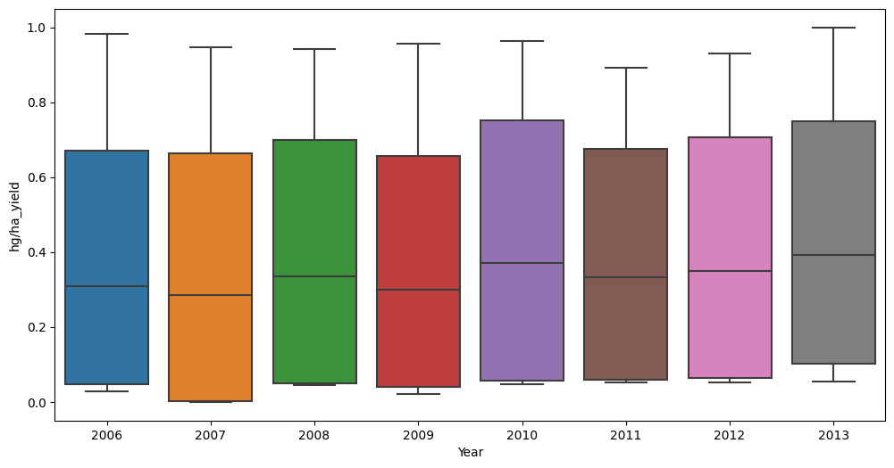

```python
plt.figure(figsize=(12, 6))
sns.boxplot(x='Year', y='hg/ha_yield', data=final_merged_df)
plt.show()
```

Data Visualization: Histograms of Selected Columns

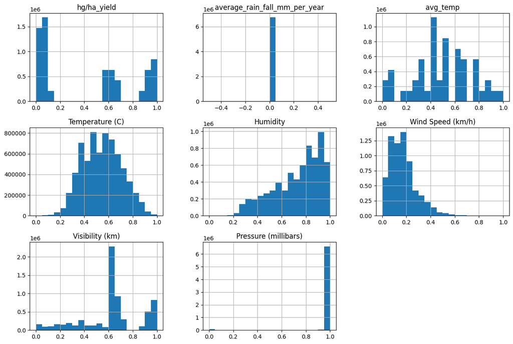

```python
selected_columns = ['hg/ha_yield', 'average_rain_fall_mm_per_year', 'avg_temp', 'Temperature (C)', 'Humidity', 'Wind Speed (km/h)', 'Visibility (km)', 'Pressure (millibars)']
final_merged_df[selected_columns].hist(bins=20, figsize=(15, 10))
plt.show()
```

Analyzing Skewness in Data

```python
skewness = final_merged_df.skew()
skewed_features = final_merged_df.drop(columns=['Year','average_rain_fall_mm_per_year']).columns

skewed_features
```

```
Index(['hg/ha_yield', 'pesticides_tonnes', 'avg_temp', 'Temperature (C)',
       'Humidity', 'Wind Speed (km/h)', 'Visibility (km)',
       'Pressure (millibars)', 'Summary_encoded'],
      dtype='object')
```

```python
skewness
```

```
Year                            -0.000320
hg/ha_yield                      0.278875
average_rain_fall_mm_per_year    0.000000
pesticides_tonnes                0.129433
avg_temp                        -0.102524
Temperature (C)                  0.069540
Humidity                        -0.692868
Wind Speed (km/h)                1.125600
Visibility (km)                 -0.510847
Pressure (millibars)            -8.507713
Summary_encoded                 -1.544924
dtype: float64
```

```python
for column in skewed_features:
    final_merged_df[column], _ = boxcox(final_merged_df[column] + 1)
```

Data Visualization: Histograms of Selected Columns

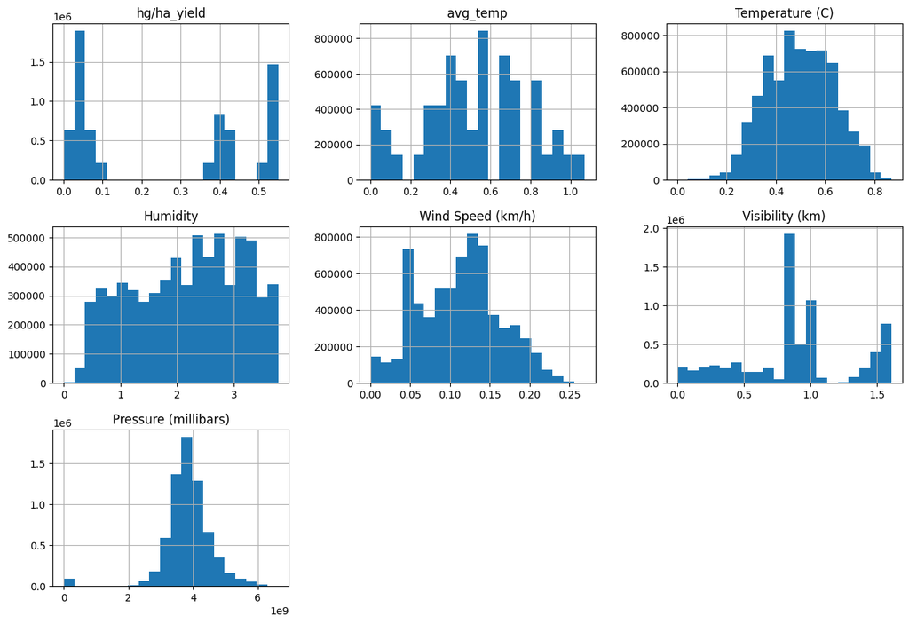

```python
selected_columns = ['hg/ha_yield',  'avg_temp', 'Temperature (C)', 'Humidity', 'Wind Speed (km/h)', 'Visibility (km)', 'Pressure (millibars)']
final_merged_df[selected_columns].hist(bins=20, figsize=(15, 10))
plt.show()
```

# Machine Learning Models

```python
X = final_merged_df.drop(columns="hg/ha_yield")
```

```python
y = final_merged_df['hg/ha_yield']
```

```python
X_train, X_temp, y_train, y_temp = train_test_split(X, y, test_size=0.3, random_state=42)
X_val, X_test, y_val, y_test = train_test_split(X_temp, y_temp, test_size=0.5, random_state=42)
```

```python
model = LinearRegression()
```

```python
model.fit(X_train, y_train)
```

```
LinearRegression()
```

```python
y_val_pred = model.predict(X_val)
```

```python
mse_val = mean_squared_error(y_val, y_val_pred)
r2_val = r2_score(y_val, y_val_pred)
```

```python
print("Mean Squared Error:", mse_val)
```

```
Mean Squared Error: 0.04740765829435346
```

```python
print("R-squared Score:", r2_val)
```

```
R-squared Score: 0.003147926482436003
```

```python
y_test_pred = model.predict(X_test)
```

```python
mse_test = mean_squared_error(y_test, y_test_pred)
r2_test = r2_score(y_test, y_test_pred)
```

```python
print("Mean Squared Error:", mse_test)
```

```
Mean Squared Error: 0.047409432048227645
```

```python
print("R-squared Score:", r2_test)
```

```
R-squared Score: 0.0029577050733607946
```

```python
def evaluate_model(model, model_name, X_train, y_train, X_val, y_val, X_test, y_test):
    # Fit the model
    model.fit(X_train, y_train)

    # Predict on validation and test sets
    y_val_pred = model.predict(X_val)
    y_test_pred = model.predict(X_test)

    # Calculate evaluation metrics for validation set
    mse_val = mean_squared_error(y_val, y_val_pred)
    r2_val = r2_score(y_val, y_val_pred)

    # Calculate evaluation metrics for test set
    mse_test = mean_squared_error(y_test, y_test_pred)
    r2_test = r2_score(y_test, y_test_pred)

    # Print evaluation metrics with model name
    print(f"Evaluation metrics for {model_name}:")
    print("Validation Set Metrics:")
    print(f"Mean Squared Error: {mse_val}")
    print(f"R-squared Score: {r2_val}\n")

    print("Test Set Metrics:")
    print(f"Mean Squared Error: {mse_test}")
    print(f"R-squared Score: {r2_test}")
```

```python
from sklearn.tree import DecisionTreeRegressor
from sklearn.ensemble import RandomForestRegressor, GradientBoostingRegressor
from sklearn.svm import SVR

# Initialize your models
dt_regressor = DecisionTreeRegressor(random_state=42)
rf_regressor = RandomForestRegressor(random_state=42)
svr_regressor = SVR()
gb_regressor = GradientBoostingRegressor(random_state=42)

# Evaluate models
evaluate_model(dt_regressor, "Decision Tree", X_train, y_train, X_val, y_val, X_test, y_test)
```

```
Evaluation metrics for Decision Tree:
Validation Set Metrics:
Mean Squared Error: 0.05542923438030096
R-squared Score: -0.16552365616580644

Test Set Metrics:
Mean Squared Error: 0.05543402864189372
R-squared Score: -0.16580327471374923
```

```python
evaluate_model(rf_regressor, "Random Forest", X_train, y_train, X_val, y_val, X_test, y_test)
```

```
Evaluation metrics for Random Forest:
Validation Set Metrics:
Mean Squared Error: 0.055480562742490774
R-squared Score: -0.1666029498099153

Test Set Metrics:
Mean Squared Error: 0.05548121420370187
R-squared Score: -0.16679560891392997
```

```python
#evaluate_model(svr_regressor, "Support Vector Machine", X_train, y_train, X_val, y_val, X_test, y_test)
```

```python
evaluate_model(gb_regressor, "Gradient Boosting", X_train, y_train, X_val, y_val, X_test, y_test)
```

```
Evaluation metrics for Gradient Boosting:
Validation Set Metrics:
Mean Squared Error: 0.04732749440704087
R-squared Score: 0.0048335515515463

Test Set Metrics:
Mean Squared Error: 0.04733905116620427
R-squared Score: 0.00443784759141852
```